# PIE benchmark: Dinamica EGO standalone (Weights of Evidence + Expander/Patcher)

Published

November 21, 2026

Dinamica EGO used the way its own documentation calibrates a land use change model, headless through `DinamicaConsole`:

1. `calibrate.ego`: Weights of Evidence ranges and coefficients for each transition on 1985 → 1991. The variables are the three lulcc explanatory factors and the distance to each other class, which Dinamica recomputes from the anterior map in every step. Weights of Evidence is a naive Bayes model: each variable contributes an additive log-odds term per range, assuming conditional independence.
2. `probabilities.ego`: the transition probability maps from the weights on the 1991 map. These are the Weights of Evidence *estimator*: `020-potentials.r` writes them into run 3000, from where every allocator of the crossing reads them like the potentials of evoland’s learners.
3. `simulate.ego`: the same probability maps, then the observed 1991 → 1999 net rates allocated by Expander and Patcher (the `AllocateTransitions` submodel shipped with Dinamica, the same one evoland’s `alloc_dinamica_spec()` drives), in a single step. This is Dinamica as shipped, a reference outside the crossing (runs 3701 …). `probabilities.ego` is separate because Expander and Patcher deplete the probability maps in place, so a map saved after allocation is not the Weights of Evidence probability.

The variables differ from evoland’s: Dinamica’s own distance-to-class maps stand in for evoland’s neighbourhood counts. That difference belongs to the estimator, as each tool engineers its predictors.

Held fixed with the evoland runs: the viable transitions, the demand, and the patch parameters and expander fractions, which are evoland’s estimates on 1985 → 1991. Native Dinamica practice sets these by hand.

```r
library(evoland.plus)
library(data.table)
source("2026-09-model-comparison/common.r")
reset_timings("dinamica-native")

model_dir <- normalizePath(file.path(pie_dir, "015-dinamica-woe"))
work_dir <- file.path(normalizePath(outputs_dir), "dinamica-native-work")
maps_dir <- file.path(outputs_dir, "maps", "dinamica-native")
unlink(work_dir, recursive = TRUE)
dir.create(work_dir, recursive = TRUE)
dir.create(maps_dir, recursive = TRUE, showWarnings = FALSE)

file.copy(
  file.path(data_dir, c(paste0("lu_", c(1985, 1991), ".tif"), paste0("ef_00", 1:3, ".tif"))),
  work_dir
)
file.copy(file.path(model_dir, c("calibrate.ego", "probabilities.ego", "simulate.ego")), work_dir)

# Dinamica 8.11.2's CalcWOfEProbabilityMap is not deterministic when run in parallel: between
# identical runs, the probabilities of the forest transitions differed in 300-1300 cells (some
# turning NA), while calibration and distance maps were identical. Single-threaded runs are
# bit-identical, so every script here runs single-threaded.
run_dinamica_serial <- function(script) {
  exec_dinamica(
    file.path(work_dir, script),
    # exec_dinamica(disable_parallel =) is gone since evoland.plus #141; the flag is passed as is
    additional_args = c(
      "-disable-parallel-steps",
      "-processors=1",
      "-disable-parallel-functors",
      "-disable-parallel-map-load"
    )
  )
}
```

# 1 Tables: demand and patch parameters

```r
# viable transitions and patch parameters as estimated by 010. In the scaling runs (080), a
# scale where evoland's calibration failed falls back to the k = 1 estimates: tiling leaves the
# patch statistics unchanged
alloc_params_path <- file.path(outputs_dir, "alloc_params_viable.csv")
if (!file.exists(alloc_params_path) && pie_scale > 1L) {
  alloc_params_path <- file.path(pie_dir, "outputs-k1", "alloc_params_viable.csv")
  message("No evoland calibration at this scale; using ", alloc_params_path)
}
alloc_params <- fread(alloc_params_path)
viable <- alloc_params[, .(id_lulc_anterior, id_lulc_posterior)]
demand <- fread(file.path(outputs_dir, "demand_transitions_1991_1999.csv"))
n_anterior <- fread(file.path(outputs_dir, "demand_class_totals.csv"))[year == 1991]

# The scripts list PIE's five transitions and bin PIE's factors (elevation in 5 m, slope in 1
# degree steps). Fit them to the case at hand: keep only the viable transitions, and on the
# synthetic landscape, whose two drivers lie in [0, 1], bin those in steps of 0.02.
viable_keys <- viable[, paste0(id_lulc_anterior, "->", id_lulc_posterior)]
for (script in c("calibrate.ego", "probabilities.ego", "simulate.ego")) {
  path <- file.path(work_dir, script)
  txt <- paste(readLines(path), collapse = "\n")
  # a skeleton block per transition: "        1->2 [ ... ]," or the last one without the comma
  for (key in setdiff(c("1->2", "1->3", "2->3", "3->1", "3->2"), viable_keys)) {
    txt <- gsub(sprintf("\\n *%s \\[[^]]*\\],?", key), "", txt)
  }
  txt <- gsub("\\],(\\n *\\];)", "]\\1", txt) # a trailing comma left by removing the last block
  # transition lists such as [1->2, 1->3, 2->3, 3->1, 3->2]
  txt <- gsub(
    "\\[1->2, 1->3, 2->3, 3->1, 3->2\\]",
    paste0("[", paste(viable_keys, collapse = ", "), "]"),
    txt
  )
  if (pie_dataset == "synthetic") {
    txt <- gsub('"static_var/ef_001" 5 ', '"static_var/ef_001" 0.02 ', txt, fixed = TRUE)
    txt <- gsub('"static_var/ef_002" 1 ', '"static_var/ef_002" 0.02 ', txt, fixed = TRUE)
  }
  writeLines(txt, path)
}

trans_rates <-
  viable[,
    .(id_lulc_anterior, id_lulc_posterior)
  ][
    demand,
    on = .(id_lulc_anterior, id_lulc_posterior),
    nomatch = NULL
  ][
    n_anterior,
    on = .(id_lulc_anterior = id_lulc),
    nomatch = NULL
  ][
    order(id_lulc_anterior, id_lulc_posterior),
    .(`From*` = id_lulc_anterior, `To*` = id_lulc_posterior, Rate = count / N)
  ]
expansion <-
  alloc_params[,
    .(
      `From*` = id_lulc_anterior,
      `To*` = id_lulc_posterior,
      Frac_expander = pmax(1e-6, pmin(1 - 1e-6, frac_expander))
    )
  ]
patcher <-
  alloc_params[,
    .(
      `From*` = id_lulc_anterior,
      `To*` = id_lulc_posterior,
      Mean_Patch_Size = mean_patch_size,
      Patch_Size_Variance = patch_size_variance,
      Patch_Isometry = patch_isometry
    )
  ]
fwrite(trans_rates, file.path(work_dir, "trans_rates.csv"))
fwrite(expansion, file.path(work_dir, "expansion_table.csv"))
fwrite(patcher, file.path(work_dir, "patcher_table.csv"))
trans_rates
```

```
   From*   To*        Rate
   <int> <int>       <num>
1:     1     2 0.008015397
2:     1     3 0.089912827
3:     3     1 0.019009658
4:     3     2 0.056850120
```

```r
expansion
```

```
   From*   To* Frac_expander
   <int> <int>         <num>
1:     1     2     0.5014164
2:     1     3     0.7669651
3:     3     1     0.8613037
4:     3     2     0.6573304
```

```r
patcher
```

```
   From*   To* Mean_Patch_Size Patch_Size_Variance Patch_Isometry
   <int> <int>           <num>               <num>          <int>
1:     1     2        1.005714         0.005714286              2
2:     1     3        1.066882         0.081915000              2
3:     3     1        1.010101         0.010101010              2
4:     3     2        1.045394         0.048738782              2
```

# 2 Calibration

```r
invisible(timed(
  "dinamica-native",
  "calibrate",
  run_dinamica_serial("calibrate.ego")
))
```

```
Logging to /home/user/evoland-experiments/2026-09-model-comparison/outputs-synthetic/dinamica-native-work/2026-11-21_22h09m59s_dinamica.log
```

```r
invisible(file.copy(
  file.path(
    work_dir,
    c("weights.dcf", "ranges.dcf", "weights_report.csv", "weights_correlation.csv")
  ),
  maps_dir,
  overwrite = TRUE
))
weights_report <- fread(file.path(work_dir, "weights_report.csv"))
setnames(weights_report, gsub("[* ]", "", names(weights_report)))
weights_report[,
  .(
    n_ranges = .N,
    n_significant = sum(Significant),
    max_abs_weight = max(abs(Weight_Coefficient))
  ),
  by = .(Transition_From, Transition_To, Variable)
]
```

```
    Transition_From Transition_To                  Variable n_ranges
              <int>         <int>                    <char>    <int>
 1:               1             2 distance_to/distance_to_2      114
 2:               1             2 distance_to/distance_to_3        3
 3:               1             2         static_var/ef_001       23
 4:               1             2         static_var/ef_002       15
 5:               1             2         static_var/ef_003      114
 6:               1             3 distance_to/distance_to_2       39
 7:               1             3 distance_to/distance_to_3        4
 8:               1             3         static_var/ef_001        7
 9:               1             3         static_var/ef_002       11
10:               1             3         static_var/ef_003       38
11:               3             1 distance_to/distance_to_1        8
12:               3             1 distance_to/distance_to_2       90
13:               3             1         static_var/ef_001       15
```

[output cut: 33 more lines]

# 3 Dinamica as shipped: allocation, one realisation per run

Dinamica draws a fresh random seed in every run unless `-predefined-seed` is given, which would make all realisations identical.

```r
for (i in seq_len(n_realisations)) {
  timed(
    "dinamica-native",
    "allocate",
    run_dinamica_serial("simulate.ego"),
    note = paste0("realisation=", i)
  )
  file.copy(
    file.path(work_dir, "posterior.tif"),
    file.path(maps_dir, sprintf("r%02d.tif", i)),
    overwrite = TRUE
  )
}
# the probability maps on their own: AllocateTransitions depletes them in place
invisible(run_dinamica_serial("probabilities.ego"))
file.copy(file.path(work_dir, "probabilities.tif"), maps_dir, overwrite = TRUE)
```

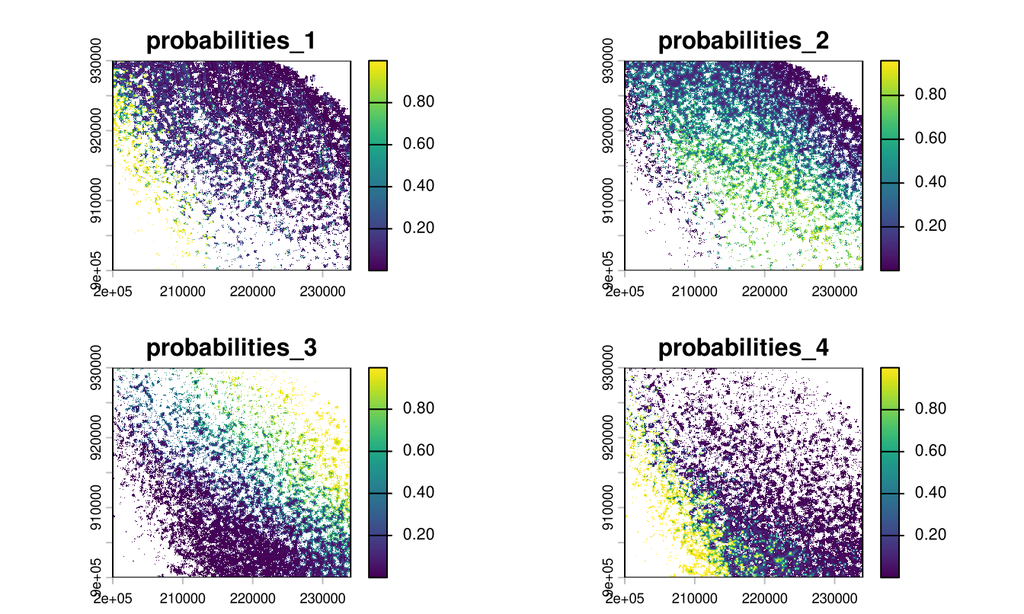

```r
terra::plot(terra::rast(file.path(maps_dir, "probabilities.tif")))
```

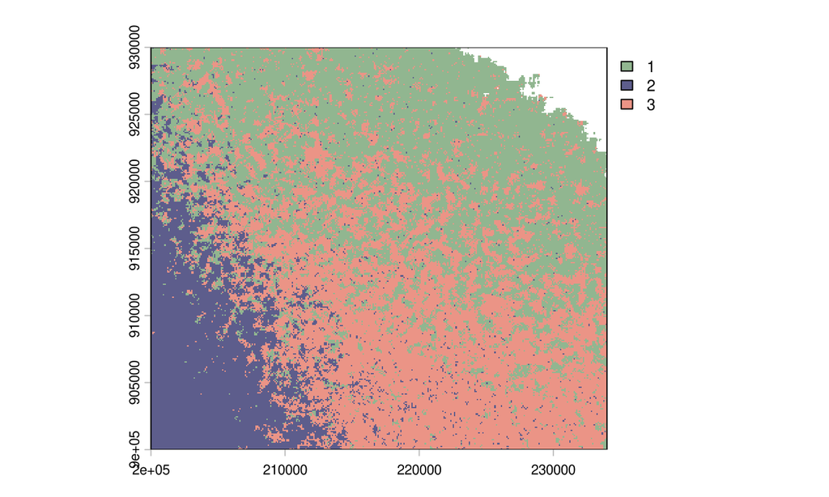

```r
terra::plot(terra::rast(file.path(maps_dir, "r01.tif")), col = lulc_colours)
```